# Лабораторная работа №3

Mathematics Typing in LaTeX

Усман Траоре

Российский университет дружбы народов, Москва, Россия

29 декабря 2025

# Цель работы

## Основная цель

Изучить основы набора математических выражений в LaTeX, освоить использование inline и display math режимов, работу с греческими буквами и математическими шрифтами, а также исследовать влияние опций класса документа `[fleqn]` и `[leqno]`.

## Рабочая директория

- использование Windows PowerShell;
- создание отдельной папки для LaTeX-упражнений;
- проверка текущего пути выполнения;
- создание и сохранение TeX-файлов с кодировкой UTF-8.

[figure not shown]

Подготовка рабочей директории

## Inline и Display Math

- inline math используется внутри строки текста;
- display math выводится отдельной формулой;
- display-формулы имеют больший размер;
- по умолчанию display-формулы центрируются.

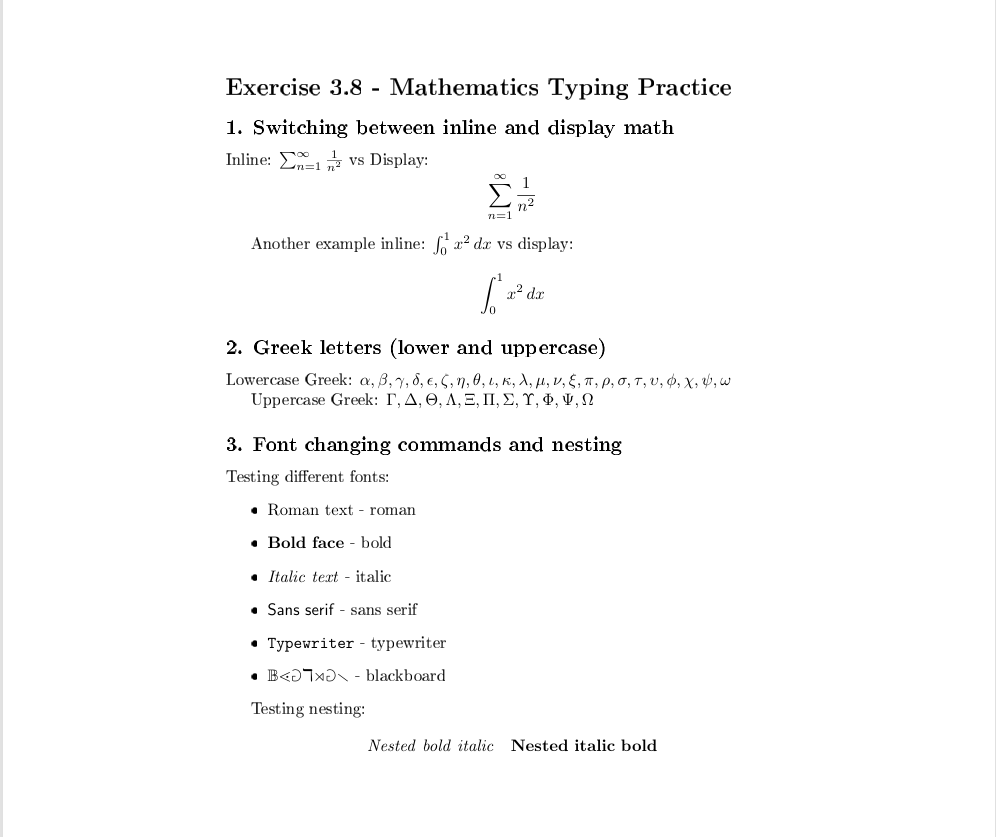

Inline и display math

## Греческие буквы

- строчные: α, β, γ, λ;
- прописные: Γ, Δ, Ω;
- имена команд логично соответствуют названиям букв;
- визуально хорошо различимы.

## Математические шрифты

Использованы: - `\mathrm` - `\mathbf` - `\mathit` - `\mathsf` - `\mathtt` - `\mathbb`

Команды позволяют изменять стиль символов в математическом режиме.

## Простая вложенность шрифтов

- комбинации из двух команд;
- сравнение порядка применения;
- видимое влияние порядка вложения.

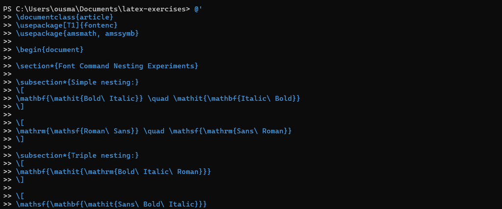

Простая вложенность

## Тройная вложенность шрифтов

- использование трёх уровней команд;
- последняя команда доминирует;
- результат соответствует ожидаемому поведению LaTeX.

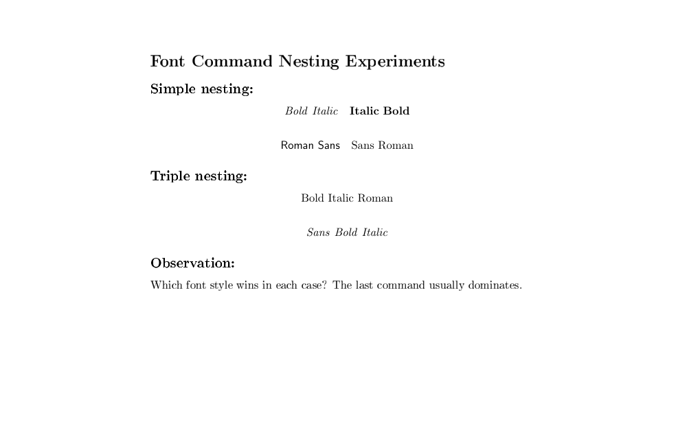

Тройная вложенность

## Компиляция с pdflatex

[figure not shown]

Компиляция pdflatex

## Опция [fleqn]

- display-формулы выравниваются по левому краю;
- центрирование отключается;
- номера уравнений остаются справа.

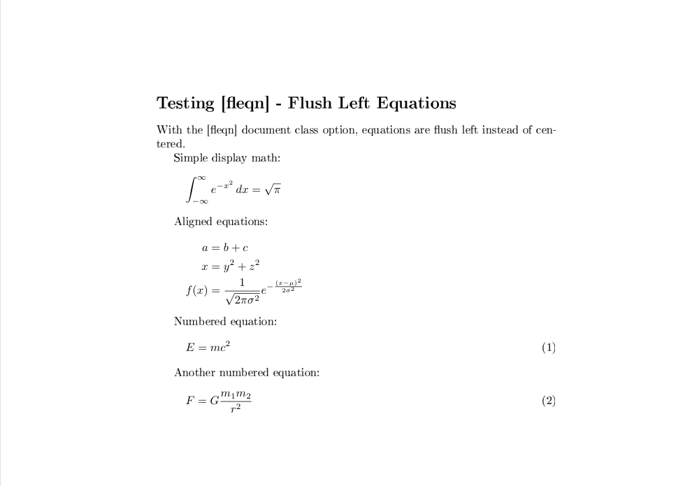

Результат с fleqn

## Опция [leqno]

- номера уравнений отображаются слева;
- сами формулы остаются центрированными;
- применяется ко всем нумерованным формулам.

[figure not shown]

## Опции [fleqn, leqno]

- формулы выровнены по левому краю;
- номера уравнений также слева;
- применяется ко всем display- и align-окружениям.

[figure not shown]

# Итоги работы

## Вывод

В ходе лабораторной работы были изучены основные приёмы набора математических выражений в LaTeX. Освоены inline и display math режимы, работа с греческими буквами и математическими шрифтами, а также влияние опций `[fleqn]` и `[leqno]`. Результаты подтверждают гибкость и удобство LaTeX при оформлении математических документов.